# HW6 - ARIMA

#### (b) fit a suitable ARIMA model to the transformed data using ARIMA();

We see a constant is included and it chose a (1,1,0) model.

```r
fit <- usa_gdp %>%
  model(ARIMA(GDP))

report(fit)
```

```
## Series: GDP
## Model: ARIMA(1,1,0) w/ drift
##
## Coefficients:
##          ar1  constant
##       0.4586  118.2764
## s.e.  0.1198    9.5123
##
## sigma^2 estimated as 5488:  log likelihood=-325.37
## AIC=656.74   AICc=657.19   BIC=662.87
```

#### (c) try some other plausible models by experimenting with the orders chosen;

We haven’t checked if there are any necessary differencing yet, so I’ll start there. It appears one is necessary on the Box-Cox transformed data.

```r
ndiffs(usa_gdp$GDP)
```

```
## [1] 1
```

All but one value is within the ACF plot bounds. A check with the KPSS test confirms the data is stationary after one order of differencing.

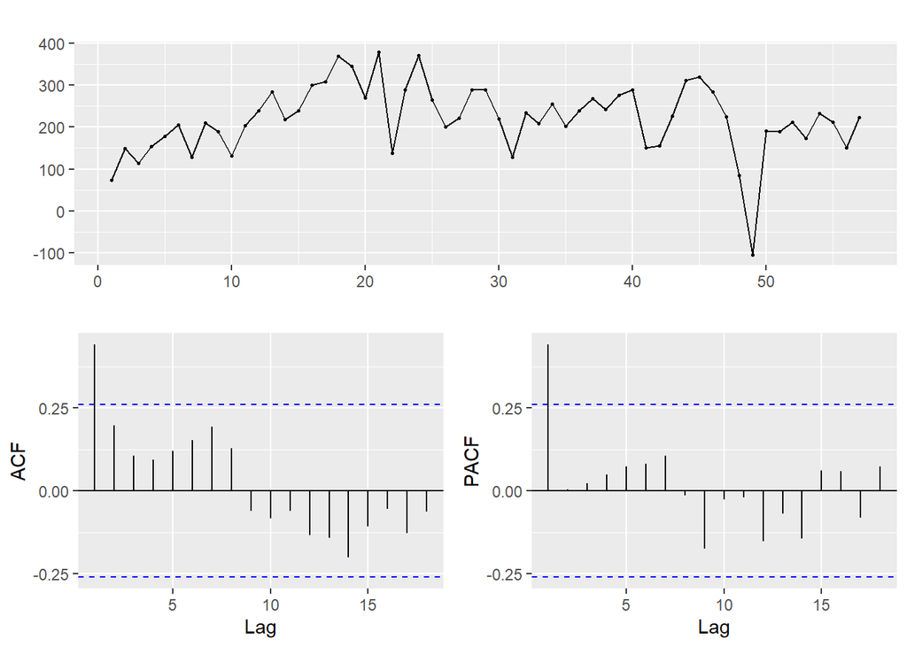

```r
ggtsdisplay(diff(usa_gdp$GDP))
```

```r
unitroot_kpss((diff(usa_gdp$GDP)))
```

```
##   kpss_stat kpss_pvalue
##   0.2082358   0.1000000
```

```r
usa_gdp_1diff <- usa_gdp %>%
  mutate(GDP_diff = difference(GDP))
```

It appears this model is still selected despite the differencing.

```r
fit2 <- usa_gdp_1diff %>%
  model(ARIMA(GDP))

report(fit2)
```

```
## Series: GDP
## Model: ARIMA(1,1,0) w/ drift
##
## Coefficients:
##          ar1  constant
##       0.4586  118.2764
## s.e.  0.1198    9.5123
##
## sigma^2 estimated as 5488:  log likelihood=-325.37
## AIC=656.74   AICc=657.19   BIC=662.87
```

I’ll try another ARIMA model to see how it performs. This one appears to perform worse than the selected model above by automation. I’d imagine with more experience and background there may be times a datascience would be able to achieve a better model than the automation picks.

```r
#model ARIMA with forced 0,1,0
fit_force <- usa_gdp_1diff %>%
  model(ARIMA(GDP ~ pdq(1,1,2)))

report(fit_force)
```

```
## Series: GDP
## Model: ARIMA(1,1,2) w/ drift
##
## Coefficients:
##          ar1      ma1      ma2  constant
##       0.8296  -0.3892  -0.1937   36.5887
## s.e.  0.2039   0.2480   0.1586    4.0053
##
## sigma^2 estimated as 5639:  log likelihood=-325.11
## AIC=660.23   AICc=661.4   BIC=670.44
```

#### (d) choose what you think is the best model and check the residual diagnostics;

I’ll choose the original model and check how it performs. The historgram is a bit skewed, however the ACF plot looks good such that the residuals are white noise.

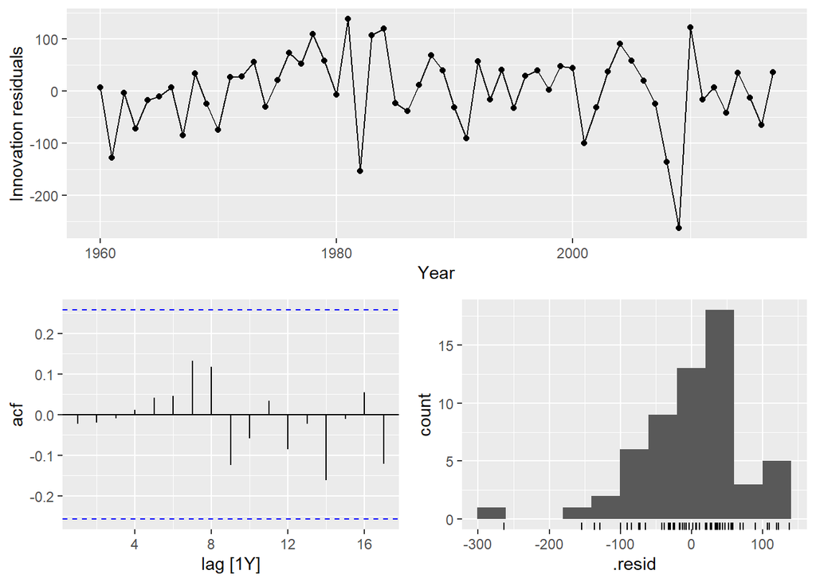

```r
gg_tsresiduals(fit)
```

#### (e) produce forecasts of your fitted model. Do the forecasts look reasonable?

A visual inspection fo the forecast looked quite reasonable, the trend continues.

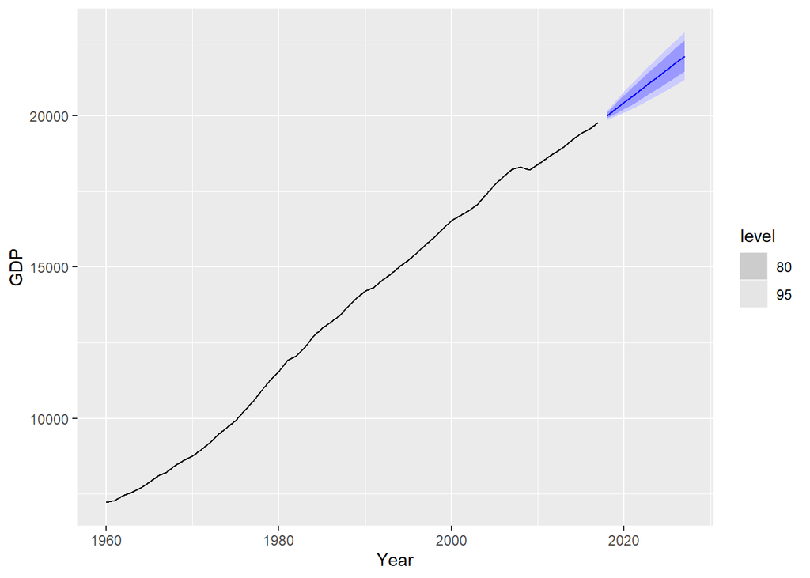

```r
fit %>%
  forecast(h = 10) %>%
  autoplot(usa_gdp)
```

#### (f) compare the results with what you would obtain using ETS() (with no transformation).

Switching back to the forecast package I build an ETS model to check it’s performance against our more complex ARIMA model. The AIC here is significantly higher, suggesting the ARIMA is performing better. This is a nice benchmark to see our more advanced model is worth the effort.

```r
ets_check <- usa_gdp$GDP %>%
  ets()

ets_check
```

```
## ETS(M,A,N)
##
## Call:
##  ets(y = .)
##
##   Smoothing parameters:
##     alpha = 0.9999
##     beta  = 0.3705
##
##   Initial states:
##     l = 7059.7092
##     b = 192.8105
##
##   sigma:  0.0059
##
##      AIC     AICc      BIC
## 743.5101 744.6639 753.8123
```